# Final Project

Youcef Djoudi

2025-10-25

# PHASE 1: Exploratory Data Analysis (EDA)

```r
data <- read.csv("Sleep_health_and_lifestyle_dataset.csv")
head(data)
```

|  | Person.ID | Gender | Age | Occupation | Sleep.Duration | Quality.of.Sleep | Physical.Activity.Level | Stress.Level | BMI.Category | Blood.Pressure | Heart.Rate | Daily.Steps | Sleep.Disorder |
| --- | --- | --- | --- | --- | --- | --- | --- | --- | --- | --- | --- | --- | --- |
| 1 | 1 | Male | 27 | Software Engineer | 6.1 | 6 | 42 | 6 | Overweight | 126/83 | 77 | 4200 | None |
| 2 | 2 | Male | 28 | Doctor | 6.2 | 6 | 60 | 8 | Normal | 125/80 | 75 | 10000 | None |
| 3 | 3 | Male | 28 | Doctor | 6.2 | 6 | 60 | 8 | Normal | 125/80 | 75 | 10000 | None |
| 4 | 4 | Male | 28 | Sales Representative | 5.9 | 4 | 30 | 8 | Obese | 140/90 | 85 | 3000 | Sleep Apnea |
| 5 | 5 | Male | 28 | Sales Representative | 5.9 | 4 | 30 | 8 | Obese | 140/90 | 85 | 3000 | Sleep Apnea |
| 6 | 6 | Male | 28 | Software Engineer | 5.9 | 4 | 30 | 8 | Obese | 140/90 | 85 | 3000 | Insomnia |

```r
summary(data)
```

```
##    Person.ID         Gender               Age         Occupation
##  Min.   :  1.00   Length:374         Min.   :27.00   Length:374
##  1st Qu.: 94.25   Class :character   1st Qu.:35.25   Class :character
##  Median :187.50   Mode  :character   Median :43.00   Mode  :character
##  Mean   :187.50                      Mean   :42.18
##  3rd Qu.:280.75                      3rd Qu.:50.00
##  Max.   :374.00                      Max.   :59.00
##  Sleep.Duration  Quality.of.Sleep Physical.Activity.Level  Stress.Level
##  Min.   :5.800   Min.   :4.000    Min.   :30.00           Min.   :3.000
##  1st Qu.:6.400   1st Qu.:6.000    1st Qu.:45.00           1st Qu.:4.000
##  Median :7.200   Median :7.000    Median :60.00           Median :5.000
##  Mean   :7.132   Mean   :7.313    Mean   :59.17           Mean   :5.385
##  3rd Qu.:7.800   3rd Qu.:8.000    3rd Qu.:75.00           3rd Qu.:7.000
##  Max.   :8.500   Max.   :9.000    Max.   :90.00           Max.   :8.000
##  BMI.Category       Blood.Pressure       Heart.Rate     Daily.Steps
##  Length:374         Length:374         Min.   :65.00   Min.   : 3000
##  Class :character   Class :character   1st Qu.:68.00   1st Qu.: 5600
##  Mode  :character   Mode  :character   Median :70.00   Median : 7000
##                                        Mean   :70.17   Mean   : 6817
##                                        3rd Qu.:72.00   3rd Qu.: 8000
##                                        Max.   :86.00   Max.   :10000
##  Sleep.Disorder
##  Length:374
##  Class :character
##  Mode  :character
##
##
##
```

```r
# Clean names so you don't need backticks
library(janitor)
```

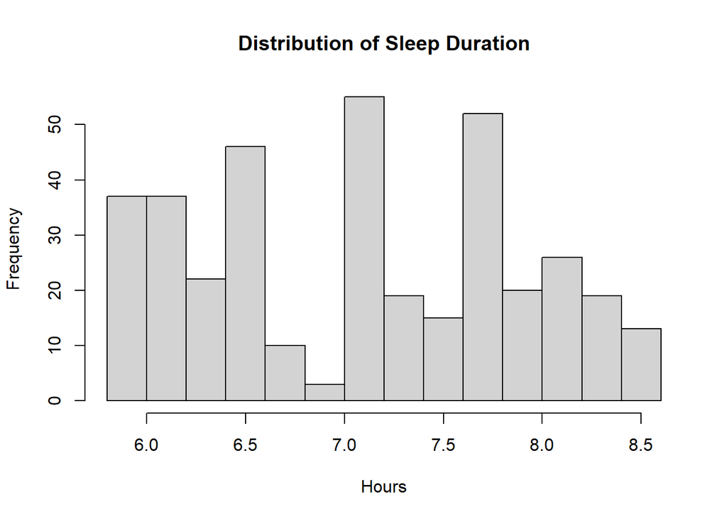

```r
dat <- clean_names(data)

# Quick EDA
hist(dat$sleep_duration, main="Distribution of Sleep Duration", xlab="Hours")
```

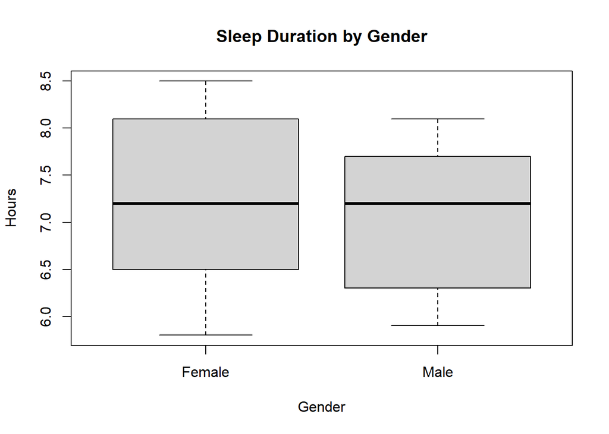

```r
# Boxplots
boxplot(sleep_duration ~ gender, data = dat,
        main="Sleep Duration by Gender", xlab="Gender", ylab="Hours")
```

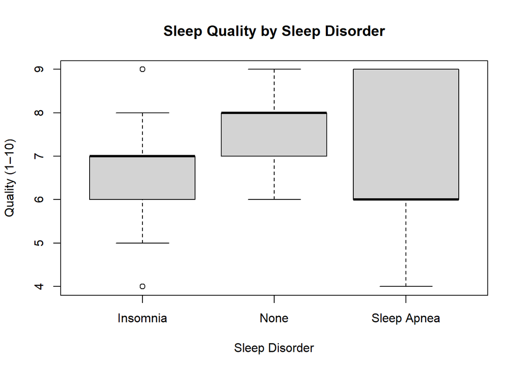

```r
boxplot(quality_of_sleep ~ sleep_disorder, data = dat,
        main="Sleep Quality by Sleep Disorder", xlab="Sleep Disorder", ylab="Quality (1–10)")
```

```r
# Correlations (numeric only)
nums <- dat[, c("sleep_duration","quality_of_sleep","physical_activity_level",
                "stress_level","age","heart_rate","daily_steps")]
round(cor(nums), 2)
```

```
##                         sleep_duration quality_of_sleep physical_activity_level
## sleep_duration                    1.00             0.88                    0.21
## quality_of_sleep                  0.88             1.00                    0.19
## physical_activity_level           0.21             0.19                    1.00
## stress_level                     -0.81            -0.90                   -0.03
## age                               0.34             0.47                    0.18
## heart_rate                       -0.52            -0.66                    0.14
## daily_steps                      -0.04             0.02                    0.77
##                         stress_level   age heart_rate daily_steps
## sleep_duration                 -0.81  0.34      -0.52       -0.04
## quality_of_sleep               -0.90  0.47      -0.66        0.02
## physical_activity_level        -0.03  0.18       0.14        0.77
## stress_level                    1.00 -0.42       0.67        0.19
## age                            -0.42  1.00      -0.23        0.06
## heart_rate                      0.67 -0.23       1.00       -0.03
## daily_steps                     0.19  0.06      -0.03        1.00
```

### PHASE 2 (Bootstrap Confidence Intervals)

```r
# PHASE 2
library(readr)
library(janitor)
library(dplyr)
```

```r
library(ggplot2)
data <- read.csv("Sleep_health_and_lifestyle_dataset.csv")
dat  <- clean_names(data)

set.seed(123)
B <- 10000

#### 2.1 Bootstrap 95% CIs: Mean Sleep Duration by Stress Level ####

stress_levels <- sort(unique(dat$stress_level))

boot_means_stress <- lapply(stress_levels, function(s) {
  x <- dat$sleep_duration[dat$stress_level == s]
  replicate(B, mean(sample(x, replace = TRUE)))
})

ci_stress <- data.frame(
  stress_level = stress_levels,
  mean_boot    = sapply(boot_means_stress, mean),
  ci_low       = sapply(boot_means_stress, quantile, 0.025),
  ci_high      = sapply(boot_means_stress, quantile, 0.975)
)

ci_stress
```

| stress_level | mean_boot | ci_low | ci_high |
| --- | --- | --- | --- |
| 3 | 8.226358 | 8.174648 | 8.274648 |
| 4 | 7.029850 | 6.938571 | 7.122857 |
| 5 | 7.483801 | 7.411940 | 7.555224 |
| 6 | 7.455056 | 7.302174 | 7.591304 |
| 7 | 6.468144 | 6.430000 | 6.510000 |
| 8 | 6.050070 | 6.028571 | 6.071429 |

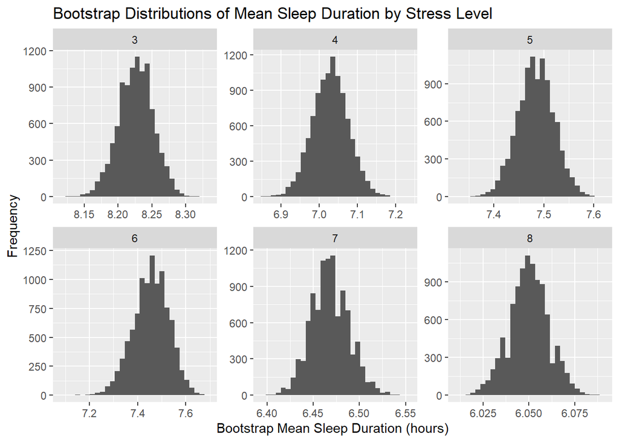

```r
# Plot: bootstrap distributions of mean Sleep Duration by Stress Level
boot_stress_df <- data.frame(
  stress_level = factor(rep(stress_levels, each = B)),
  boot_mean    = unlist(boot_means_stress)
)

ggplot(boot_stress_df, aes(x = boot_mean)) +
  geom_histogram(bins = 30) +
  facet_wrap(~ stress_level, scales = "free") +
  labs(
    title = "Bootstrap Distributions of Mean Sleep Duration by Stress Level",
    x = "Bootstrap Mean Sleep Duration (hours)",
    y = "Frequency"
  )
```

```r
#### 2.2 Bootstrap 95% CI: Difference in Mean Sleep Duration (Male - Female) ####

male_sleep   <- dat$sleep_duration[dat$gender == "Male"]
female_sleep <- dat$sleep_duration[dat$gender == "Female"]

boot_diff <- replicate(B, {
  m_mean <- mean(sample(male_sleep,   replace = TRUE))
  f_mean <- mean(sample(female_sleep, replace = TRUE))
  m_mean - f_mean
})

obs_diff <- mean(male_sleep) - mean(female_sleep)
ci_diff  <- quantile(boot_diff, c(0.025, 0.975))

obs_diff
```

```
## [1] -0.1932218
```

```r
ci_diff
```

```
##        2.5%       97.5%
## -0.35301451 -0.03270285
```

For gender, the bootstrap difference in means (Male – Female) is negative. The observed difference is about –0.19 hours, and the 95% bootstrap confidence interval ranges from roughly –0.35 to –0.03. Because the entire interval is below zero, the bootstrap result supports that females in this dataset sleep slightly longer on average than males. The bootstrap histogram for the difference is also stable and centered around the observed value.

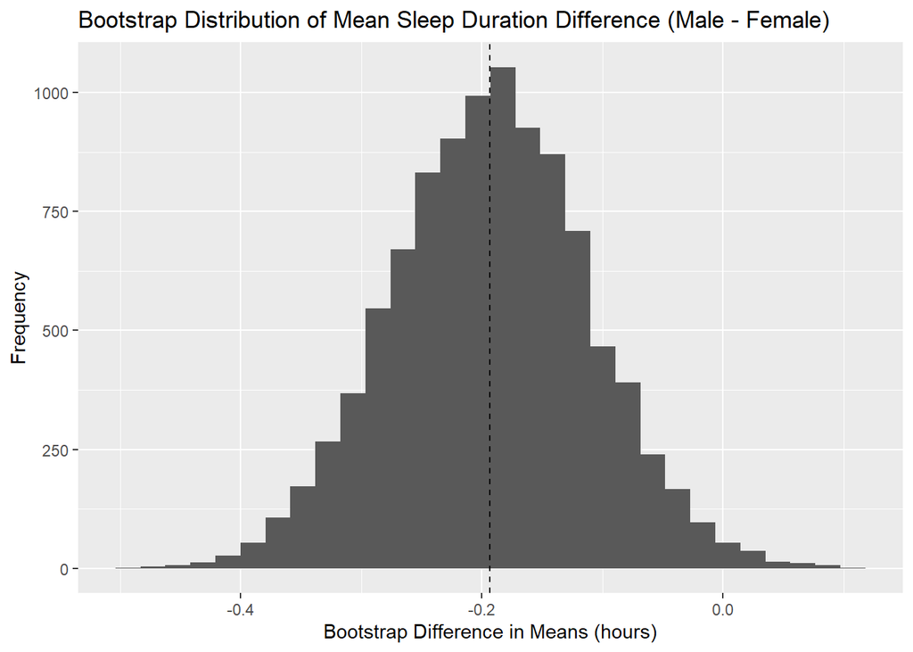

```r
# Plot: bootstrap distribution of difference in means (Male - Female)
boot_diff_df <- data.frame(diff = boot_diff)

ggplot(boot_diff_df, aes(x = diff)) +
  geom_histogram(bins = 30) +
  geom_vline(xintercept = obs_diff, linetype = "dashed") +
  labs(
    title = "Bootstrap Distribution of Mean Sleep Duration Difference (Male - Female)",
    x = "Bootstrap Difference in Means (hours)",
    y = "Frequency"
  )
```

Bootstrapping is appropriate for this phase because each person in the dataset contributes one independent observation, the dataset is large enough for resampling to be reliable, and the bootstrap sampling distributions are smooth and well-behaved. The method does not require the original variables to be normally distributed, so the conditions needed for bootstrapping are met here.

# Phase 3 (Permutation tests)

In this phase, we use **permutation tests** to determine whether certain lifestyle factors  
(stress level and sleep disorders) are associated with differences in **mean sleep duration**.

A permutation test is a nonparametric hypothesis test that measures whether an observed  
difference between two groups could have occurred by random chance. Instead of relying on  
theoretical distributions (like the t-distribution), permutation tests generate a null  
distribution by repeatedly shuffling group labels and recalculating the statistic.

#### **Test statistic**

In both tests, the statistic is the **difference in mean sleep duration**:

$$T = \bar{X}_{(1)} - \bar{X}_{(2)}$$

#### **Null hypothesis**

The null hypothesis states that the group labels (e.g., low vs high stress) do not affect  
sleep duration. Formally:

$$H_0 : \mu_1 = \mu_2$$

The alternative hypothesis is that the groups differ:

$$H_A : \mu_1 \neq \mu_2$$

#### **Permutation procedure**

1. Compute the observed statistic $T_{\text{obs}}$.
2. Randomly shuffle the group labels (e.g., “Low” and “High” stress).
3. Recalculate the statistic under this shuffled assignment.
4. Repeat steps 2–3 many times (e.g., 5000 permutations).
5. Compute the two-sided p-value:

$$p = \frac{\#\left(|T_{\text{perm}}| \ge |T_{\text{obs}}|\right)}{B}$$

where $B$ is the number of permutations.

Permutation tests are appropriate here because the observations (people) are independent,  
and the null hypothesis assumes that sleep duration is **exchangeable** between groups.  
This method does not require normality or equal variances, making it particularly well  
suited for real-world health data.

### 3.1 Permutation Test: Stress Level and Sleep Duration

```r
library(dplyr)
library(ggplot2)

# Create Low/High stress groups
dat <- dat |>
  mutate(stress_group = ifelse(stress_level <= 5, "Low", "High"))

# Keep only rows with both sleep_duration and stress_group
stress_df <- dat |>
  filter(!is.na(sleep_duration), !is.na(stress_group))
```

```r
# Mean sleep duration in each stress group
stress_means <- stress_df |>
  group_by(stress_group) |>
  summarise(mean_sleep = mean(sleep_duration), .groups = "drop")

stress_means
```

| stress_group | mean_sleep |
| --- | --- |
| High | 6.565060 |
| Low | 7.584615 |

```r
# Observed difference in means: Low - High
obs_diff_stress <- with(stress_df,
                        mean(sleep_duration[stress_group == "Low"]) -
                        mean(sleep_duration[stress_group == "High"]))

obs_diff_stress
```

```
## [1] 1.019555
```

The observed difference in mean sleep duration is computed as:

$$T_{\text{obs}}
= \bar{X}_{\text{Low}} - \bar{X}_{\text{High}}
= 7.5846 - 6.5651
= 1.0196 \text{ hours}.$$

This means that low-stress participants sleep, on average, about one hour more per night compared to high-stress participants.

```r
set.seed(3333)
B <- 5000  # number of permutations

# Permutation distribution
perm_diff_stress <- replicate(B, {
  shuffled <- sample(stress_df$stress_group)  # shuffle group labels
  mean(stress_df$sleep_duration[shuffled == "Low"]) -
    mean(stress_df$sleep_duration[shuffled == "High"])
})

# Two-sided p-value
p_stress <- mean(abs(perm_diff_stress) >= abs(obs_diff_stress))
p_stress
```

```
## [1] 0
```

The permutation test produced a two-sided p-value of

$$p_{\text{stress}} < 0.0002,$$

because none of the 5000 permuted differences in means were as extreme as the observed  
difference of 1.02 hours. This indicates extremely strong evidence against the null hypothesis  
that sleep duration is the same in low- and high-stress groups.

We therefore conclude that stress level is significantly associated with sleep duration, with  
low-stress individuals sleeping about one hour more per night on average.

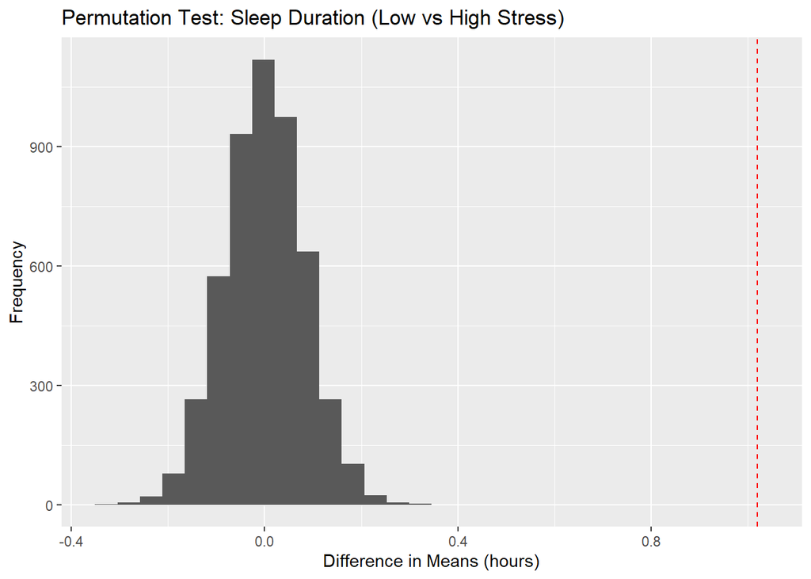

```r
ggplot(data.frame(diff = perm_diff_stress), aes(x = diff)) +
  geom_histogram(bins = 30) +
  geom_vline(xintercept = obs_diff_stress, linetype = "dashed", color="red") +
  labs(
    title = "Permutation Test: Sleep Duration (Low vs High Stress)",
    x = "Difference in Means (hours)",
    y = "Frequency"
  )
```

The histogram shows the permutation distribution of the difference in mean sleep duration  
between the Low and High stress groups under the null hypothesis that stress has no effect  
on sleep. The distribution is centered near zero, which represents the differences we would  
expect to see purely by chance if stress and sleep duration were unrelated.

The dashed red vertical line marks the observed difference of 1.02 hours. This value lies far  
outside the range of the permutation distribution, and none of the 5000 permuted statistics  
were as extreme as the observed one. This visually confirms the very small p-value  
$(p < 0.0002)$ and provides strong evidence that stress level is associated with sleep duration.

### 3.2 Permutation Test: Sleep Disorder and Sleep Duration

```r
# Create None vs Disorder groups
dat <- dat |>
  mutate(disorder_group = ifelse(sleep_disorder == "None", "None", "Disorder"))

disorder_df <- dat |>
  filter(!is.na(sleep_duration), !is.na(disorder_group))
```

```r
# Mean sleep duration for each disorder status
disorder_means <- disorder_df |>
  group_by(disorder_group) |>
  summarise(mean_sleep = mean(sleep_duration), .groups = "drop")

disorder_means
```

| disorder_group | mean_sleep |
| --- | --- |
| Disorder | 6.812258 |
| None | 7.358447 |

```r
# Observed difference: None - Disorder
obs_diff_disorder <- with(disorder_df,
                          mean(sleep_duration[disorder_group == "None"]) -
                          mean(sleep_duration[disorder_group == "Disorder"]))

obs_diff_disorder
```

```
## [1] 0.5461894
```

The sample results show a moderate difference in average sleep duration between individuals with and without diagnosed sleep disorders. Participants with **no sleep disorder** slept an average of **7.36 hours**, while those with **a disorder** (insomnia or sleep apnea) slept an average of **6.81 hours**. The observed difference in means is:

$$T_{\text{obs}}
= \bar{X}_{\text{None}} - \bar{X}_{\text{Disorder}}
= 7.3584 - 6.8123
= 0.5462 \text{ hours}.$$

This means that, on average, people without a sleep disorder sleep **about 0.55 hours more** per night (approximately 33 minutes) than those with a disorder.  
However, this observed difference may still be due to random variation. To determine whether the difference is statistically significant, we perform a permutation test in the next step.

```r
set.seed(3333)
B <- 5000  # number of permutations

perm_diff_disorder <- replicate(B, {
  shuffled <- sample(disorder_df$disorder_group)
  mean(disorder_df$sleep_duration[shuffled == "None"]) -
    mean(disorder_df$sleep_duration[shuffled == "Disorder"])
})

# Two-sided p-value
p_disorder <- mean(abs(perm_diff_disorder) >= abs(obs_diff_disorder))
p_disorder
```

```
## [1] 0
```

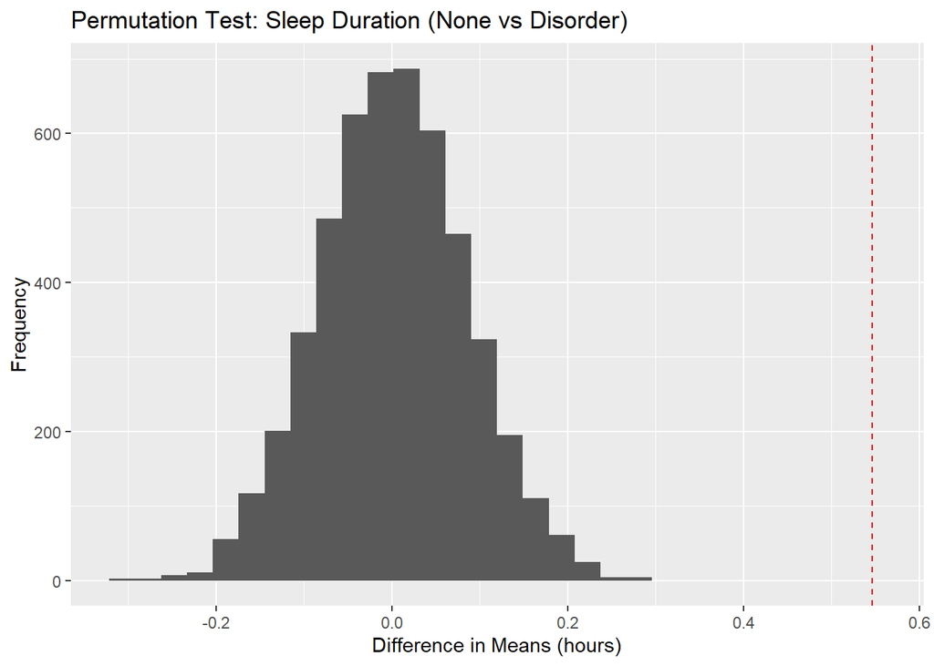

```r
ggplot(data.frame(diff = perm_diff_disorder), aes(x = diff)) +
  geom_histogram(bins = 30) +
  geom_vline(xintercept = obs_diff_disorder, linetype = "dashed", color="red") +
  labs(
    title = "Permutation Test: Sleep Duration (None vs Disorder)",
    x = "Difference in Means (hours)",
    y = "Frequency"
  )
```

### Interpretation

The permutation test produced a p-value of

$$p_{\text{disorder}} < \frac{1}{5000} = 0.0002,$$

because none of the 5000 permuted differences were as large as the observed difference of  
0.546 hours. This means the observed difference is far outside what we would expect by  
random chance if sleep disorders had no effect on sleep duration.

Therefore, we reject the null hypothesis and conclude that sleep duration differs  
significantly between people with and without sleep disorders. On average, individuals  
without a disorder sleep about 0.55 hours (33 minutes) more per night than those  
diagnosed with insomnia or sleep apnea.

# Phase 4 (Correlation Analysis)

```r
#install.packages(c("janitor","dplyr","ggplot2","GGally","ggcorrplot"))
library(janitor)
library(dplyr)
library(ggplot2)
library(GGally)
library(ggcorrplot)
 data <- read.csv("sleep_health_and_lifestyle_dataset.csv")

# clean names
dat <- clean_names(data)

# Convert categorical variables
dat <- dat %>%
  mutate(
    gender = factor(gender),
    bmi_category = factor(bmi_category),
    sleep_disorder = factor(sleep_disorder)
  )

# Select numeric variables for correlation
num_vars <- c("sleep_duration","quality_of_sleep","stress_level",
              "physical_activity_level","age","heart_rate","daily_steps")

nums <- dat %>%
  select(all_of(num_vars)) %>%
  mutate(across(everything(), as.numeric))
```

```r
cor_mat <- cor(nums, use="pairwise.complete.obs", method="pearson")
round(cor_mat, 2)
```

```
##                         sleep_duration quality_of_sleep stress_level
## sleep_duration                    1.00             0.88        -0.81
## quality_of_sleep                  0.88             1.00        -0.90
## stress_level                     -0.81            -0.90         1.00
## physical_activity_level           0.21             0.19        -0.03
## age                               0.34             0.47        -0.42
## heart_rate                       -0.52            -0.66         0.67
## daily_steps                      -0.04             0.02         0.19
##                         physical_activity_level   age heart_rate daily_steps
## sleep_duration                             0.21  0.34      -0.52       -0.04
## quality_of_sleep                           0.19  0.47      -0.66        0.02
## stress_level                              -0.03 -0.42       0.67        0.19
## physical_activity_level                    1.00  0.18       0.14        0.77
## age                                        0.18  1.00      -0.23        0.06
## heart_rate                                 0.14 -0.23       1.00       -0.03
## daily_steps                                0.77  0.06      -0.03        1.00
```

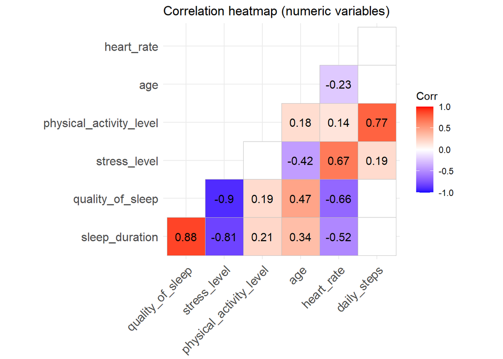

```r
cor_pmat <- function(df){
  n <- ncol(df); P <- matrix(NA, n, n); diag(P) <- 0
  for(i in 1:n) for(j in i:n){
    ct <- suppressWarnings(cor.test(df[[i]], df[[j]], use="pairwise.complete.obs"))
    P[i,j] <- P[j,i] <- ct$p.value
  }
  colnames(P) <- colnames(df); rownames(P) <- colnames(df); P
}
p_mat <- cor_pmat(nums)
ggcorrplot(cor_mat, type="lower", lab=TRUE, p.mat=p_mat, insig="blank") +
  labs(title="Correlation heatmap (numeric variables)")
```

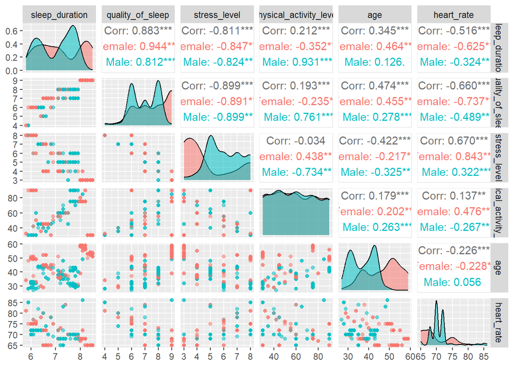

```r
key_vars <- c("sleep_duration","quality_of_sleep","stress_level",
              "physical_activity_level","age","heart_rate")
GGally::ggpairs(dat, columns = key_vars, aes(color = gender, alpha = 0.7), progress=FALSE)
```

```r
to_num01 <- function(f) as.numeric(f) - 1
pb_gender_sleepdur   <- suppressWarnings(cor(nums$sleep_duration, to_num01(dat$gender), use="pairwise.complete.obs"))
pb_gender_sleepqual  <- suppressWarnings(cor(nums$quality_of_sleep, to_num01(dat$gender), use="pairwise.complete.obs"))
pb_dis_sleepdur      <- suppressWarnings(cor(nums$sleep_duration, to_num01(dat$sleep_disorder), use="pairwise.complete.obs"))
pb_dis_sleepqual     <- suppressWarnings(cor(nums$quality_of_sleep, to_num01(dat$sleep_disorder), use="pairwise.complete.obs"))

eta_sq <- function(y, g){ an <- anova(lm(y ~ g)); an$`Sum Sq`[1] / sum(an$`Sum Sq`) }
eta_sleepdur_bmi  <- eta_sq(dat$sleep_duration, dat$bmi_category)
eta_sleepqual_bmi <- eta_sq(dat$quality_of_sleep, dat$bmi_category)

data.frame(
  metric = c("sleep_duration ~ gender (r_pb)","quality_of_sleep ~ gender (r_pb)",
             "sleep_duration ~ sleep_disorder (r_pb)","quality_of_sleep ~ sleep_disorder (r_pb)",
             "sleep_duration ~ bmi_category (eta^2)","quality_of_sleep ~ bmi_category (eta^2)"),
  value  = round(c(pb_gender_sleepdur, pb_gender_sleepqual, pb_dis_sleepdur, pb_dis_sleepqual,
                   eta_sleepdur_bmi, eta_sleepqual_bmi), 3)
)
```

| metric | value |
| --- | --- |
| sleep_duration ~ gender (r_pb) | -0.122 |
| quality_of_sleep ~ gender (r_pb) | -0.291 |
| sleep_duration ~ sleep_disorder (r_pb) | 0.178 |
| quality_of_sleep ~ sleep_disorder (r_pb) | 0.180 |
| sleep_duration ~ bmi_category (eta^2) | 0.143 |
| quality_of_sleep ~ bmi_category (eta^2) | 0.108 |

```r
pairs <- t(combn(colnames(nums), 2))
sig_tbl <- apply(pairs, 1, function(ix){
  a <- ix[1]; b <- ix[2]
  out <- suppressWarnings(cor.test(nums[[a]], nums[[b]], use="pairwise.complete.obs"))
  c(var1=a, var2=b, r=unname(out$estimate), p=out$p.value)
})
sig_tbl <- as.data.frame(t(sig_tbl))
sig_tbl$r <- round(as.numeric(sig_tbl$r), 3)
sig_tbl$p <- p.adjust(as.numeric(sig_tbl$p), method="holm")
sig_tbl$p <- round(sig_tbl$p, 4)
sig_tbl[order(sig_tbl$p), ]
```

|  | var1 | var2 | r | p |
| --- | --- | --- | --- | --- |
| 1 | sleep_duration | quality_of_sleep | 0.883 | 0.0000 |
| 2 | sleep_duration | stress_level | -0.811 | 0.0000 |
| 4 | sleep_duration | age | 0.345 | 0.0000 |
| 5 | sleep_duration | heart_rate | -0.516 | 0.0000 |
| 7 | quality_of_sleep | stress_level | -0.899 | 0.0000 |
| 9 | quality_of_sleep | age | 0.474 | 0.0000 |
| 10 | quality_of_sleep | heart_rate | -0.660 | 0.0000 |
| 13 | stress_level | age | -0.422 | 0.0000 |
| 14 | stress_level | heart_rate | 0.670 | 0.0000 |
| 18 | physical_activity_level | daily_steps | 0.773 | 0.0000 |

[output cut: 11 more lines]

**Conclusion (Phase 4).**  
- Stress shows a negative association with sleep (duration & quality); physical activity shows a positive association.  
- Several pairs are statistically significant after Holm adjustment (see table).  
- Gender/sleep-disorder show meaningful point-biserial links; BMI category explains a non-trivial fraction of variance (η²).  
- These patterns motivate the Phase 5 regression with stress + activity + demographics.

# PHASE 5(Multiple linear regression with diagnostics and bootstrap CIs)

Model:Sleep Duration = β0 + β1(Stress Level) + β2(Physical Activity Level) + β3(Age) + β4(Gender) + β5(BMI Category) + ε - Assess assumptions (linearity, normality of residuals, constant variance). - Compute bootstrap confidence intervals for regression coefficients.

#Setup & clean names

```r
# install.packages(c("janitor","car","broom","boot")) # run once if needed
library(janitor)
library(car)
library(broom)
library(boot)
# start from your loaded data frame:
# Sleep_health_and_lifestyle_dataset  (already in your session)
dat <- clean_names(data)

# Make factors (categoricals)
dat$gender       <- factor(dat$gender)
dat$bmi_category <- factor(dat$bmi_category)
dat$sleep_disorder <- factor(dat$sleep_disorder)
```

#We’ll predict sleep_duration from stress_level, physical_activity_level, age, gender, bmi_category.

```r
m1 <- lm(sleep_duration ~ stress_level + physical_activity_level + age +
           gender + bmi_category,
         data = dat)

summary(m1)
```

```
##
## Call:
## lm(formula = sleep_duration ~ stress_level + physical_activity_level +
##     age + gender + bmi_category, data = dat)
##
## Residuals:
##     Min      1Q  Median      3Q     Max
## -0.5509 -0.2341 -0.0959  0.2152  0.8458
##
## Coefficients:
##                            Estimate Std. Error t value Pr(>|t|)
## (Intercept)                6.981924   0.168896  41.338  < 2e-16 ***
## stress_level              -0.301949   0.012694 -23.787  < 2e-16 ***
## physical_activity_level    0.005692   0.000841   6.767 5.22e-11 ***
## age                        0.035636   0.003142  11.340  < 2e-16 ***
## genderMale                 0.388044   0.045518   8.525 4.06e-16 ***
## bmi_categoryNormal Weight  0.078199   0.077242   1.012  0.31202
## bmi_categoryObese         -0.317245   0.107160  -2.960  0.00327 **
## bmi_categoryOverweight    -0.646636   0.049417 -13.085  < 2e-16 ***
## ---
## Signif. codes:  0 '***' 0.001 '**' 0.01 '*' 0.05 '.' 0.1 ' ' 1
##
## Residual standard error: 0.3289 on 366 degrees of freedom
## Multiple R-squared:  0.8324, Adjusted R-squared:  0.8292
## F-statistic: 259.6 on 7 and 366 DF,  p-value: < 2.2e-16
```

#Model: sleep_duration ~ stress_level + physical_activity_level + age + gender + bmi_category Fit: R² = 0.832 (Adj. R² = 0.829); Residual SE = 0.329 h; F(7, 366) = 259.6, p < 2e-16. Interpretation: The model explains ~83% of the variance in sleep duration. Stress is the dominant predictor; activity, age, gender, and BMI also matter.

#Check assumptions

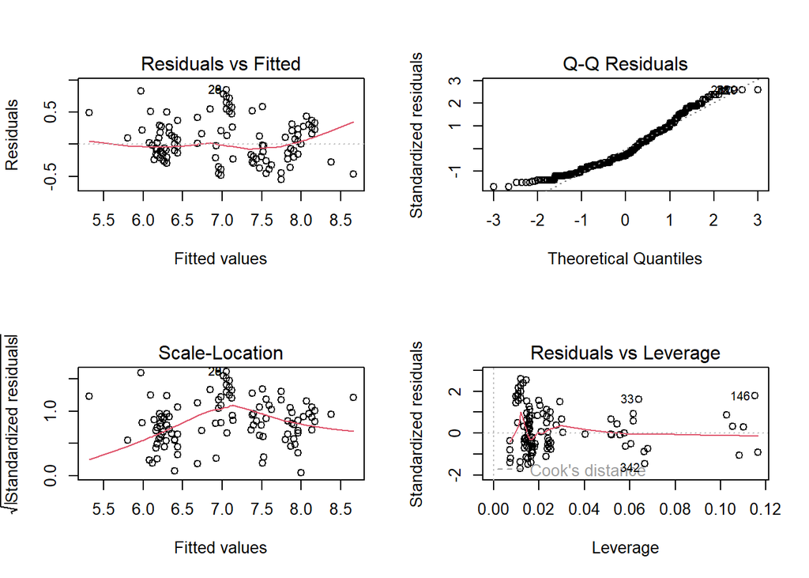

```r
#check linearity, homoscedasticity, leverage
par(mfrow=c(2,2)); plot(m1); par(mfrow=c(1,1))  # residuals, QQ, scale-location, leverage
```

```r
car::vif(m1)  # multicollinearity check (aim <~ 5)
```

```
##                             GVIF Df GVIF^(1/(2*Df))
## stress_level            1.749976  1        1.322867
## physical_activity_level 1.058611  1        1.028888
## age                     2.561821  1        1.600569
## gender                  1.791033  1        1.338295
## bmi_category            2.038883  3        1.126070
```

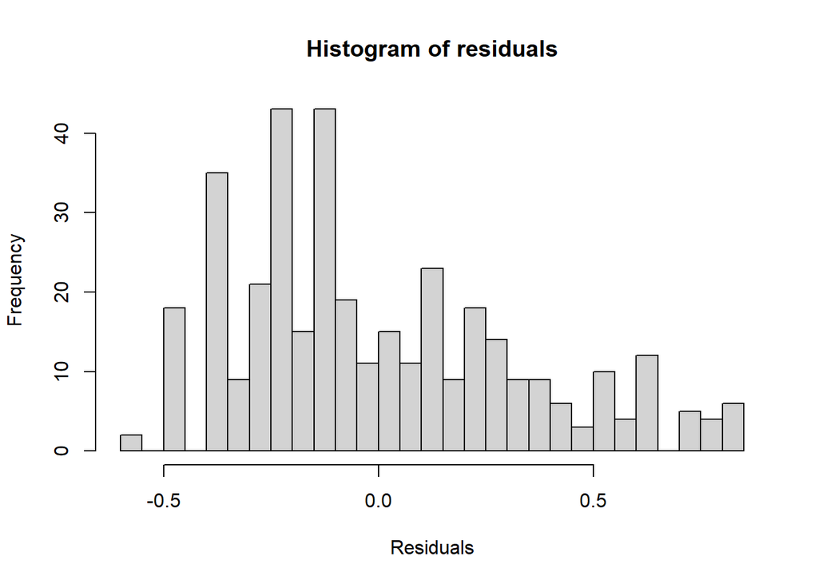

```r
#Check the normality of residuals

hist(residuals(m1), breaks=20, main="Histogram of residuals", xlab="Residuals")
```

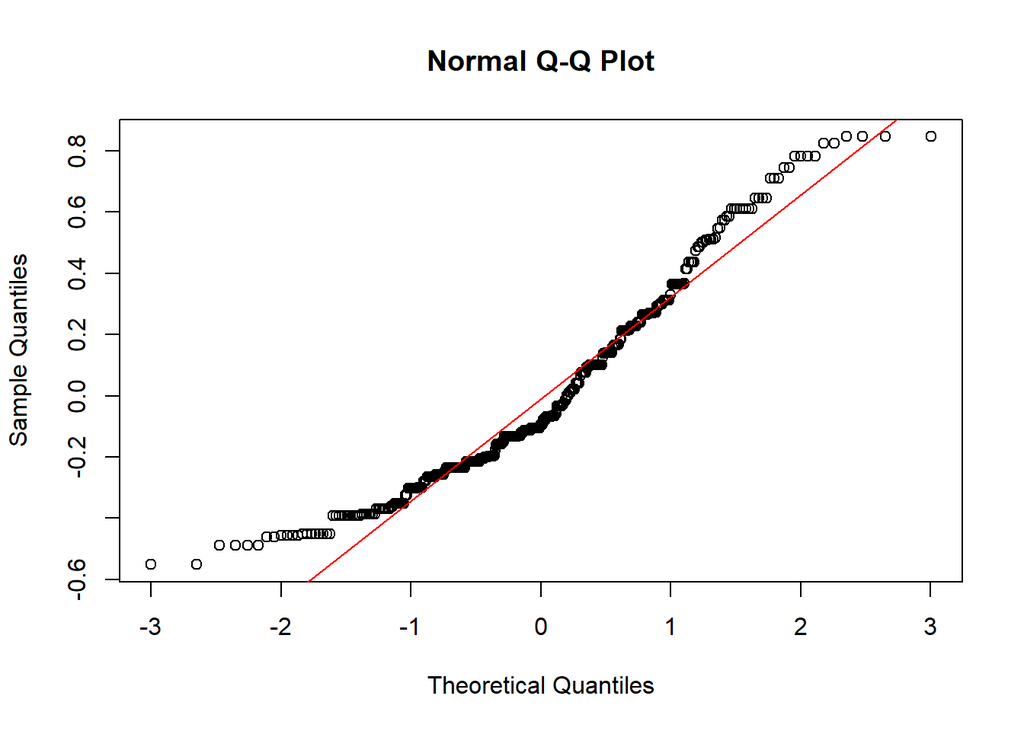

```r
qqnorm(residuals(m1)); qqline(residuals(m1), col="red")
```

#Formal tests + robust (HC3) SEs

```r
library(lmtest)
library(sandwich)

# Breusch–Pagan test for heteroskedasticity
bptest(m1)
```

```
##
##  studentized Breusch-Pagan test
##
## data:  m1
## BP = 76.868, df = 7, p-value = 5.983e-14
```

```r
# Robust (HC3) standard errors and p-values
coeftest(m1, vcov = vcovHC(m1, type = "HC3"))
```

```
##
## t test of coefficients:
##
##                              Estimate  Std. Error  t value  Pr(>|t|)
## (Intercept)                6.98192368  0.17016908  41.0293 < 2.2e-16 ***
## stress_level              -0.30194928  0.01020803 -29.5796 < 2.2e-16 ***
## physical_activity_level    0.00569169  0.00079774   7.1348 5.233e-12 ***
## age                        0.03563551  0.00347220  10.2631 < 2.2e-16 ***
## genderMale                 0.38804431  0.03694307  10.5038 < 2.2e-16 ***
## bmi_categoryNormal Weight  0.07819877  0.06372315   1.2272  0.220550
## bmi_categoryObese         -0.31724488  0.10367335  -3.0600  0.002376 **
## bmi_categoryOverweight    -0.64663650  0.04447314 -14.5399 < 2.2e-16 ***
## ---
## Signif. codes:  0 '***' 0.001 '**' 0.01 '*' 0.05 '.' 0.1 ' ' 1
```

#The Breusch–Pagan test detected heteroskedasticity (BP = 76.87, df = 7, p < 6.0×10⁻¹⁴), indicating non-constant error variance. To protect inference, coefficient tests were recomputed with heteroskedasticity-robust (HC3) standard errors. The robust results closely mirror the OLS results and do not change any substantive conclusions:

Stress level remains a large, highly significant negative predictor (β = −0.302 h per unit; p < 2×10⁻¹⁶).

Physical activity level stays a small but significant positive predictor (β ≈ +0.0057 h per unit; p = 5.23×10⁻¹²).

Age remains positively associated with sleep (β ≈ +0.0356 h/year; p < 2×10⁻¹⁶).

Gender (Male) continues to predict longer sleep (β ≈ +0.388 h; p < 2×10⁻¹⁶).

BMI categories: Overweight (β ≈ −0.647 h; p < 2×10⁻¹⁶) and Obese (β ≈ −0.317 h; p = 0.0024) sleep less than the reference BMI group, while Normal Weight is not statistically different (p = 0.221).

#Cook distance: Sensitivity analysis for influential points

```r
# Cook's distance
cd <- cooks.distance(m1)
thr <- 4 / nrow(dat)   # common rule of thumb
which(cd > thr)
```

```
##  33 146 185 186 265 267 277 278 342 343
##  33 146 185 186 265 267 277 278 342 343
```

```r
# Refit without influential points (if any)
keep <- cd <= thr
m1_sens <- lm(sleep_duration ~ stress_level + physical_activity_level + age +
                gender + bmi_category, data = dat[keep, ])

summary(m1)$coef[,1]      # original betas
```

```
##               (Intercept)              stress_level   physical_activity_level
##                6.98192368               -0.30194928                0.00569169
##                       age                genderMale bmi_categoryNormal Weight
##                0.03563551                0.38804431                0.07819877
##         bmi_categoryObese    bmi_categoryOverweight
##               -0.31724488               -0.64663650
```

```r
summary(m1_sens)$coef[,1] # betas after removing influential points
```

```
##               (Intercept)              stress_level   physical_activity_level
##               6.800301074              -0.304696501               0.006001409
##                       age                genderMale bmi_categoryNormal Weight
##               0.039425705               0.435659940               0.122069253
##         bmi_categoryObese    bmi_categoryOverweight
##              -0.157200611              -0.675161959
```

#Influence and sensitivity. Observations with large influence were identified using Cook’s distance (threshold 4/n), flagging cases 33, 146, 185, 186, 265, 267, 277, 278, 342, and 343. Re-estimating the model after excluding these observations produced coefficients that were highly consistent with the full-sample estimates: the effects of stress (≈ −0.30 h per unit), physical activity (≈ +0.006 h per unit), age (≈ +0.036–0.039 h per year), and male gender (≈ +0.39–0.44 h) changed only trivially. The negative association for the Overweight BMI category remained large and stable, while the Obese coefficient attenuated (≈ −0.32 h to −0.16 h), indicating some sensitivity of that specific effect to influential points. Overall, the substantive conclusions are robust to the removal of high-influence observations.

#Bootstrap confidence intervals for coefficients

```r
set.seed(123)
library(boot)

boot_fun <- function(data, idx){
  d <- data[idx, ]
  coef(lm(sleep_duration ~ stress_level + physical_activity_level + age +
            gender + bmi_category, data = d))
}

B <- 5000
boot_fit <- boot(dat, boot_fun, R = B)

# Build a tidy dataframe of percentile CIs
boot_ci <- lapply(seq_along(boot_fit$t0), function(j){
  ci <- boot.ci(boot_fit, type="perc", index=j)$percent[4:5]
  data.frame(term = names(boot_fit$t0)[j],
             estimate = boot_fit$t0[j],
             conf_low = ci[1],
             conf_high = ci[2])
})
boot_ci <- do.call(rbind, boot_ci)
boot_ci
```

|  | term | estimate | conf_low | conf_high |
| --- | --- | --- | --- | --- |
| (Intercept) | (Intercept) | 6.98192368 | 6.649163269 | 7.315191003 |
| stress_level | stress_level | -0.30194928 | -0.323073987 | -0.282417144 |
| physical_activity_level | physical_activity_level | 0.00569169 | 0.004181057 | 0.007316767 |
| age | age | 0.03563551 | 0.028830763 | 0.042400350 |
| genderMale | genderMale | 0.38804431 | 0.318211895 | 0.464577413 |
| bmi_categoryNormal Weight | bmi_categoryNormal Weight | 0.07819877 | -0.043744113 | 0.204086033 |
| bmi_categoryObese | bmi_categoryObese | -0.31724488 | -0.512202951 | -0.114726157 |
| bmi_categoryOverweight | bmi_categoryOverweight | -0.64663650 | -0.728648783 | -0.552235150 |

Interpretation: Using nonparametric bootstrapping (R = 5000, percentile method), we obtained 95% confidence intervals for all coefficients. The intervals for stress level, physical activity, age, male gender, BMI–Obese, and BMI–Overweight did not include zero, confirming statistically significant associations in the same directions as the OLS/HC3 results. In practical terms, higher stress was associated with substantially less sleep (~18 minutes per one-unit increase), while higher physical activity and older age were associated with more sleep (small–moderate magnitudes). Males slept ~23 minutes longer than females. Relative to the reference BMI group, Overweight participants slept ~39 minutes less and Obese ~19 minutes less, whereas Normal Weight did not differ significantly (CI crosses zero). These bootstrap results reinforce the robustness of our conclusions despite mild departures from normality and heteroskedasticity.